# 04. 판단 예측

실제 상황에서 판단하여 예측하는 일은 흔합니다. 과거 데이터가 전혀 없거나 새로운 상품이 이제 막 나왔을 때 또는 시장에 새로운 경쟁사가 들어왔을 때 아니면 완전히 새로우면서 독특한 시장 상황과 같은 많은 경우에는, 판단 예측(judgmental forecasting)을 사용할 수 밖에 없습니다. 예를 들어, 호주 정부는 2012년 12월에, 담뱃갑에 회사 로고를 사용하는 것을 금지하고 모든 담뱃갑에 어두운 녹색을 사용하도록 하는 법안을 세계 최초로 통과시켰습니다. 과거 사례가 없기 때문에 이러한 정책의 효과를 예측하려면 판단을 사용해야만 합니다.

데이터가 완벽하지 않거나 어떤 지연 기간 이후의 것만 이용할 수 있는 경우도 있습니다. 예를 들면, 분기별로 GDP 자료만 사용할 수 있기 때문에, 중앙 은행들은 현재 예보(nowcasting)라고 알려진 절차인 경제 활동의 현재 수준을 예측하는 작업에서 판단을 포함시킵니다.

이 분야의 연구는 판단 예측(judgmental forecasting)의 정확도가

**(i) 예측하는 사람이 특정 분야의 중요한 지식과**

**(ii) 더욱 시기 적절한 최신 정보를 갖고 있을 때**

증가한다는 것을 보였습니다. 판단을 이용한 접근 방식은 변화나 정보 또는 사건에 따라 빠르게 조정할 수 있습니다.

수년간, 판단 예측(judgmental forecasting)에 대한 필요를 인식하면서 과학으로써 판단 예측을 수용하는 정도가 증가했습니다. 더욱 중요한 점은, 잘 짜여진 조직적인 접근 방식을 구현하여 판단 예측 분야의 향상을 직접적으로 살필 수 있게 되면서, 판단 예측의 질도 증가했다는 것입니다. 판단 예측에는 주관적이고 여러 단점이 있다는 것을 알아차리는 것은 중요합니다. 하지만, 조직적이면서 잘 짜여진 접근 방식을 구현하여 이러한 단점을 막을 수 있고 예측 정확도도 눈에 띄게 향상시킬 수 있습니다.

다음은 판단 예측(judgmental forecasting)을 사용하는 3가지 일반적인 상황입니다.

**(i) 이용할 수 있는 데이터가 없어서, 통계 기법을 적용할 수 없고 할 수 있는 접근 방식은 판단 예측밖에 없는 경우.**

**(ii) 이용할 수 있는 데이터가 있고, 통계적인 예측값을 생성했고, 그리고 나서 판단을 이용하여 조정하는 경우.**

**(iii) 이용할 수 있는 데이터가 있고, 통계적 예측값과 판단 예측값을 독립적으로 내고 그 둘을 결합하는 경우.**

(이 책의 다른 장에서 다룰 것처럼) 데이터를 사용할 수 있는 경우에는 통계적인 기법을 적용하는 방법을 선호하고, 이 장에서 사용하는 판단 예측은 항상 시작점으로만 사용해야할 것을 분명히 합니다. 통계적인 예측값은 일반적으로 판단만 이용하여 얻은 예측값보다 더 뛰어납니다. 이 장의 대부분에서 사용할 수 있는 데이터가 없는 첫 번째 상황에 집중하겠고, 이 장의 마지막 부분에서 판단을 이용하여 통계 예측값을 조정하는 내용을 이야기하겠습니다.

## 04.01. 한계점에 주의하기

판단 예측값은 주관적이라, 편견이나 한계점에 노출될 수밖에 없습니다.

판단 예측값은 일관적이지 않을 수 있습니다. 항상 같은 수학적인 식에서 나오는 통계적인 예측값과는 달리, **판단 예측값은 사람의 인지력에 크게 의존하기에 이러한 한계점에 취약합니다.**

예를 들면, 제한적인 기억 때문에 최근의 사건을 사건이 실제로 일어난 것보다 더 중요하게 생각할 수도 있고, 훨씬 더 과거에 일어난 무게감 있는 사건을 무시할 수도 있습니다. 또는 제한적인 관심 때문에 중요한 정보를 빠뜨리는 결과가 생길 수도 있습니다. 혹은 인과 관계를 잘못 이해하여 잘못된 추론으로 이어질 수도 있습니다. 게다가, 인간의 판단은 심리학적인 요인의 효과에 따라 변할 수 있습니다. 관리자 있는 상황을 생각해봅시다. 어떤 날은 그 관리자가 긍정적인 기분으로 있다면 예측값은 다소 낙관적일 수 있고, 또 다른 어떤 날에 부정적인 기분으로 있다면, 다소 덜 낙관적인 예측값을 낼 수 있습니다.

판단은 개인적이거나 정치적인 쟁점 때문에 흐려질 수 있습니다. 이 상황에서 ( 1 장에서 정의한 것처럼) 목표와 예측값은 분리되지 않습니다. 예를 들어, 만약 자신이 낸 예측값을 판매량 예측값을(목표) 정하는데 사용할 것을 판매 담당하는 직원이 안다고 하면, (즉, 기대 목표치를 초과하는) 좋은 결과를 보여주기 위해 이러한 예측값을 낮게 잡는 경향을 나타낼 수도 있습니다. 목표와 예측값이 잘 분리되어있는 상황에서도, 낙관적이거나 희망적인 생각 때문에 판단이 흐려질 수 있습니다. 예를 들어, 신제품 출시를 목표로 하고 일하는 팀이 제품이 실패할 것이라고 예측하는 상황은 매우 드물 것입니다. 뒤에서 살펴보겠지만, 그룹 회의를 준비할 때 이렇게 낙관하는 자세가 강조될 수 있습니다. “여러분의 마케팅 담당 동료들과 영업 담당 동료의 열정을 경계하시길 바랍니다”

**판단 예측에서 흔히 나타나지만 원치 않는 또 다른 특징은 정착효과(the effect of anchoring)입니다.** 이 경우에, 연이은 예측값은 조정된 초기 기준점과 비슷하거나 이에 수렴하는 경향이 있습니다. 예를 들면, 흔히 마지막 관측치를 기준점으로 둡니다. 예측하는 사람이 선행 정보에 과도하게 영향을 받아서, 예측 과정에서 마지막 관측치에 더 큰 가중치를 줍니다. 정착 효과는 보수적인 생각을 낳고, 현재에 더 가까운 정보와 새로운 정보를 과소평가하는 것으로 이어지며, 그것 때문에 조직적인 편향이 생깁니다.

## 04.02. 핵심 원리

판단 예측할 때 체계적이고 잘 짜여진 접근 방식을 사용하면 이전 절에서 살펴본 판단 예측의 한계 때문에 나타나는 부정적인 효과를 줄이는데 도움이 됩니다. 접근 방식은 다음과 같은 원리를 따라야 합니다.

### 예측 작업을 간결하고 분명하게 정하기

예측하려는 시도를 정하고 예측 작업을 표현할 때 주의할 필요가 있습니다. 작업이 무엇인지에 대해 모두가 분명하게 아는 것이 중요합니다. 모든 용어 정의는 애매하거나 모호하지 않고 분명하면서 포괄적이어야 합니다. 또한, 예측하는 사람이 집중하지 못하게 만들 수 있는 감정을 자극하는 용어나 상관없는 정보를 피하는 것이 중요합니다. 뒤에서 소개하는 델파이(Delphi) 기법에서, 예측 작업을 정하기 전에 정보를 모으는 사전 작업을 수행하는 것이 종종 유용할 수 있습니다.

### 체계적인 접근 방식을 구현하기

예측 작업과 관련 있는 정보를 분류하는 검사표 등의 체계적인 판단 예측 방식을 사용하여 예측의 정확도와 일관성을 높일 수 있습니다. 예를 들어, 어떤 정보가 중요하고 정보에 가중치를 어떻게 줄지 확인하는 것이 도움이 될 수 있습니다. 신제품의 수요를 예측할 때, 어떤 요인을 고려해야만 하고 그런 요인을 어떻게 고려할 수 있겠습니까? 가격, 품질, 경쟁 제품의 품질, 당시 경제 상황, 제품의 예상 고객층 등이 되어야만 하겠습니까? 가능한 가장 좋은 체계적인 접근 방식으로 이어질 판단 규칙을 모으기 위해 의미 있는 노력과 자원을 쏟을만한 가치가 있습니다.

### 기록하고 정당화하기

체계적인 접근 방식에서 실행한 판단 규칙과 가정을 형식화하고 문서 형태로 만드는 것은 같은 규칙을 반복적으로 실행할 수 있어서 일관성을 높일 수 있습니다. 또한, 예측하는 사람에게 낸 예측값을 문서 형태로 만들고 정당화하라고 요청하는 것은 편향을 감소하는 효과로 이어질 수 있습니다. 더욱이, 형식적인 문서로 만드는 작업은 다음에 제안하는 체계적인 평가 과정을 아주 수월하게 만듭니다.

### 예측값을 체계적으로 평가하기

예측 과정을 체계적으로 추적하고 관찰하는 것을 통해 뜻밖의 불규칙한 점을 찾아낼 수 있습니다. 특히, 예측값을 꾸준히 기록하고, 관련된 관측값을 사용할 수 있을 때, 피드백 목적으로 기록한 것을 사용합시다. 여러분이 예측가로서 최선을 다해도, 여러분이 다루는 환경은 자주 변합니다. 변화가 일어나고, 여러분은 판단 규칙과 가정을 평가하기 위해 이러한 변화를 추적 관찰할 필요가 있습니다. 피드백과 평가는 예측가의 학습과 예측 정확도를 높이는데 도움을 줍니다.

### 예측가와 사용자를 구분하기

예측값을 가지고 행동 계획을 실행할 책임이 있는 사람과 같이, 예측값을 사용할 사람이 직접 예측 작업을 수행하는 경우에는 예측 정확도가 낮아질 수 있습니다. 여기에서 예측하는 것이란, 예측값에 영향을 줄 수 있는 어떠한 미래 사건에 관한 지식과 과거 데이터를 포함한 주어진 모든 이용 가능한 정보를 가지고, 할 수 있는 한 정확하게 미래를 예측하는 작업이라는 정의를 다시 강조하겠습니다. 예측가와 사용자는 분명하게 구분되어야 합니다. 흔한 예는 신제품을 출시하는 상황입니다. 예측은 신제품의 판매량을 합리적으로 추정한 값이어야 합니다. 이것은 회사의 재정 목표치에 맞추기 위해 담당자가 기대하거나 희망하는 판매량과 상당히 다를 수 있습니다. 이 경우에, 예측가는 사용자와 현실성 확인 작업을 할 것입니다.

예측하는 사람이 예측값을 가지고 잠재적인 사용자와 빈틈없이 대화하는 것은 중요합니다. 사용자가 예측가와 단절되어있거나 멀리 떨어져 있다고 느낄 수 있고, 예측값을 전적으로 신뢰하지 못할 수도 있습니다. 과정을 설명하고 명확하게하고 예측값을 내는 기본 가정을 정당화하는 작업은 사용자에게 어떤 신뢰감을 제공할 것입니다.

그런 다음에 예측값을 사용하고 실행될 수 있는 방법은 분명히 경영 의사 결정에 따라 바뀔 것입니다. 예를 들어, 예측이 구매와 재고 수준을 안내하는데 사용됨에 따라, (지나치게 낙관하게 되어) 경영진이 상향 예측에 맞추어 결정할 수도 있습니다. 비용 편익 분석(cost-benefit analysis)을 통해 초과 재고 보관 비용이 유실 판매보다 훨씬 낮다고 증명된 이후에 이러한 결정을 수용할 것입니다. 이러한 종류의 맞춤은 예측 과정의 일부가 아니라, 목표치를 정하거나 공급 계획의 일부가 되어야 합니다. 반대로, 예측값이 목표치로 사용될 때, 목표치를 더 쉽게 초과할 수 있도록 낮게 설정될 수 있습니다. 다시 한번, 목표치를 정하는 것은 예측값을 내는 것과 다르고, 이 두 가지를 혼동해서는 안 됩니다.

다음의 예제는 저자가 수행한 산업 분야 컨설팅 사례에서 가져온 것입니다. 두 가지 대조되는 종류의 판단 예측을 나타냅니다. 하나는 지금까지 설명한 원리를 고려한 것이고, 다른 하나는 그렇게 하지 않은 것입니다.

### 예제: 제약 혜택 제도

PBS 예측 과정에서 84개의 그룹에 속한 PBS 목록에 있는 의약품을 사용했고, 의약품 양의 예측값을 내고 각 그룹과 4개의 PBS 범주들 각각에 대한 전체 지출의 예측치도 냈습니다. 전체 672개의 시계열을 사용했습니다. 이 예측 과정이 PBS에 할당된 정부 예산을 정하는데 도움이 됩니다. 이 예산은 매년 70억 호주 달러 이상이며 이는 GDP의 1%에 달합니다.

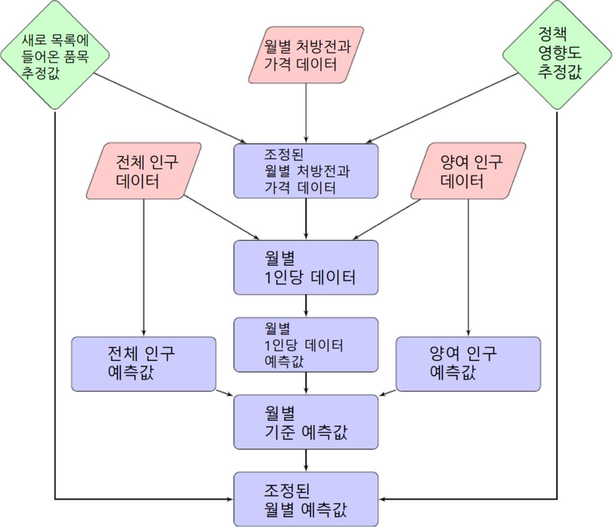

새롭게 목록에 들어온 의약품과 새로운 정책의 효과 추정에 대해 판단 예측값을 낸 것입니다. 이러한 항목을 녹색으로 표시했습니다. 분홍색 항목은 다양한 정부 부서와 관계 기관에서 얻어서 사용한 데이터를 나타냅니다. 파란색 항목은 제공된 데이터로 계산된 것을 나타냅니다. 새롭게 목록에 들어온 것과 새로운 정책을 고려하여 판단으로 데이터를 조정하였고, 예측값도 판단으로 조정하였습니다. 양여 인구와 전체 인구 크기 둘 다 변하기 때문에 예측값들을 1인당 결과로 냈고, 전체 크기와 매월 지출의 예측값을 얻기 위해 이것을 예측 인구와 곱했습니다.

저자 중의 한 명(힌드만; Hyndman)은 몇 년 전에 예측 과정에 대한 평가를 부탁 받았습니다. 새롭게 목록에 들어온 것과 새로운 정책 효과(policy impacts)에 대해 판단을 사용한 것이 통계 모델만 사용한 것보다 더 나은 예측값을 내는 것을 확인했습니다. 하지만, 더욱 구조화되고 체계적인 과정을 통해 예측 정확도와 일관성을 늘릴 수 있다는 것도 발견했습니다. 특별히 정책 효과에 대해서 그랬습니다.

새롭게 목록에 들어온 것을 예측하기: PBS에 의약품을 추가해달라고 신청한 회사에 해당 의약품의 다음과 같은 다양한 측면에 대한 자세한 예측값을 제출하도록 하였습니다. 예측된 환자 수, 신약의 시장 점유율, 대체 효과 등. 제약 혜택 자문 위원회(Pharmaceutical Benefits Advisory Committee)는 이러한 예측값을 내기 위해 매우 구조화되고 체계적인 접근 방식을 설명하는 지침을 제공했고, 해당 과정의 각 단계마다 주의깊게 작성한 문서를 요청했습니다. 이렇게 구조화된 과정은 고의적인 자체 제공 편향이 일어날 가능도(likelihood)와 효과를 줄이는데 도움이 됩니다. 부-위원회가 회사 예측값에 대한 두 가지 세부 평가 단계를 맡았습니다. 한 단계는 의약품이 PBS에 추가되기 전에 하였고, 다른 하나는 추가된 후에 하였습니다. 마지막으로, 새롭게 목록에 들어온 것 몇몇을 골라서 이것에 대해 목록에 추가된 지 12개월 지났을 때와 24개월 지났을 때 관측값과 예측값을 비교하였고, 회사에 의견을 받기 위해 결과값을 회사에 돌려 보냈습니다.

정책 영향 예측값: 새로 목록에 들어온 것들에 대해 사용한 매우 구조화된 과정에 비해, 정책 영향 예측값에 대해서는 체계적인 절차가 없었습니다. 많은 경우에, 조그만 팀이 정책 영향의 예측값을 계산했고, 이러한 예측값은 한 사람의 작업에 심하게 의존합니다. 예측값은 일반적으로 공식 검토 과정의 대상이 아니었습니다. 정책 영향에 대한 판단 예측값을 어떻게 구성할 지에 대한 지침이 없었고, 이러한 예측값을 어떻게 얻었는지와 예측값에 어떤 가정이 깔려있는지 등을 다루는 적절한 문서가 부족할 때도 있었습니다.

그래서, 몇 가지 변경 사항을 제안했습니다:

1. 더욱 체계적이고 구조화된 예측 접근 방식을 장려하기 위해 새로운 정책 영향을 예측하기 위한 지침을 개발해야합니다;
2. 예측값을 낼 때 들어가는 모든 가정을 포함하여 각각의 경우에 예측 방법론이 문서 형태로 정리되어야 합니다;
3. 새로운 정책 예측값은 조직의 다른 영역에 속한 적어도 두 사람 이상이 내야합니다;
4. 각각의 새로운 정책을 시행하고 나서 1년 후에 검토 위원회가 예측값을 점검해야합니다. 특별히 유의미하게 연간 예상 비용이나 절감 효과가 있는 새로운 정책에 대해서 그렇습니다. 점검 위원회에는 예측값을 낼 때 참여했던 사람만 들어가는 것이 아니라 다른 사람들도 함께 포함시켜야 합니다.

이러한 제안 사항은 이 절에서 간단하게 소개한 원리를 반영한 것입니다.

### 04.03. 델파이 기법

델파이 기법은 1950년대에 랜드(Rand Corporation)의 올라프 헬머(Olaf Helmer)와 노르만 댈키(Norman Dalkey)가 특정한 군사 문제를 다루기 위해 개발한 것입니다. 이 기법은 집단이 낸 예측값이 개인이 낸 예측치보다 더 정확하다는 핵심 가정에 의존합니다. 델파이 기법의 목적은 구조화된 반복이라는 방식을 가지고 전문가의 모임에서 얻은 합의로 내는 예측값을 구성하는 것입니다. 과정을 진행하고 관리하기 위해 진행자가 임명됩니다. 델파이 기법에는 일반적으로 다음과 같은 단계가 있습니다:

1. 전문가 위원회가 모입니다.
2. 예측 작업과 과제를 정하고 각 전문가에게 나눠줍니다.
3. 각 전문가는 초기 예측값과 타당한 이유를 돌려줍니다. 피드백을 제공하기 위해 모아서 요약합니다.
4. 각 전문가에게 피드백을 제공합니다. 각 전문가는 피드백에 비춰보아 예측값을 검토합니다. 이 과정은 만족스러운 수준으로 합의가 이뤄질 때까지 반복될 수도 있습니다.
5. 각 전문가의 예측값을 모아서 최종 예측값을 구성합니다.

델파이 기법의 각 단계마다 어려운 부분이 있습니다. 이어지는 내용에서는 각 항목에 대 한 몇몇 제안과 관련된 이야기를 하려고 합니다

### 전문가와 익명성

진행자의 첫 번째 과제는 예측 작업에 이바지할 수 있는 전문가 모임을 찾는 것입니다. 보통은 다양한 분야에서 온 5명에서 20명 사이의 전문가로 합니다. 전문가는 예측값을 제출하고 이에 대한 정성적으로 타당한 자세한 이유도 제공합니다.

**델파이 기법의 핵심적인 특징은 참여하는 전문가의 익명성이 항상 유지된다는 것입니다.** 전문가가 예측값을 낼 때 정치적이거나 사회적인 요인에 의해 영향받을 수 없다는 것을 의미합니다. 더욱이, 모든 전문가에게 발언권이 똑같이 주어지고 낸 예측값에 대해 모두 똑같이 책임을 집니다. 이를 통해 모임이 열리는 장소에서 몇몇 구성원이 참여하지 않거나 다른 이가 주도하는 상황을 막습니다. 나이나 조직에서의 위치 또는 성격에 따라 지나치게 영향을 행사하는 구성원을 막기도 합니다. 모임을 구성할 때 좌석 배치와 같은 간단한 것조차 모임의 효율성에 영향을 줄 수 있다는 의견도 있었습니다. 더욱이, 그룹 모임을 구성하는 것이 열정을 높이고 개개인의 판단에 영향을 주어 낙관주의와 과신에 이르게 한다는 충분한 증거가 있습니다

전문가가 물리적인 장소에서 무리지어 만날 필요가 없다는 것은 익명성의 장점 중의 하나입니다. 이렇게 하면 다양한 기술과 전문 지식을 가진 다양한 위치에 있는 전문가를 모을 가능성이 높아진다는 장점이 있습니다. 더욱이, 여행 비용과 이동의 불편함을 없애서 과정에 드는 비용을 효율적으로 만들고, 전문가 그룹은 함께 모이는 시간을 정하지 않아도 되고 제출 기한만 맞추면 되니 과정을 유연하게 진행할 수 있게 됩니다.

### 델파이 기법에서 예측 작업을 설정하기

이 환경에서, 예측 작업을 설정하기 전에 전문가 그룹으로부터 예비 정보 수집 단계를 수행하는 것이 유용할 수 있습니다. 또는, 전문가 그룹이 초기 예측값과 타당한 이유를 제출하면, 모든 전문가가 공유하지 않는 중요한 정보를 진행자가 피드백을 모을 때 찾아낼 수 있습니다.

### 피드백

전문가에게 피드백을 주는 과정은 예측값에 대한 요약 통계와 정성적으로 타당한 이유를 요약한 개요를 포함해야합니다. 수치 데이터 요약본과 시각적으로 묘사한 내용을 전문가의 예측값을 요약하는데 사용할 수 있습니다.

진행자가 피드백을 통제하기 때문에, 참여한 사람의 관심을 끌 것과 전문가의 정보가 가장 필요한 분야가 있을 수 있습니다. 예를 들어, 진행자는 4분위 범위를 넘어서는 응답과 이러한 예측값에 대한 정성적으로 타당한 이유에 대해 전문가의 관심을 유도할 수도 있습니다.

### 반복

예측값을 제출하고, 피드백을 받고, 예측값을 검토하는 등의 해당 전문가가 담당하는 과정은 해당 전문가 사이에서 만족스러운 수준으로 합의가 이뤄질 때까지 반복됩니다. 만족스러운 합의는 예측치에 있어서 완벽한 합의를 의미하는 것이 아닙니다. 이는 단순히 응답의 다양성이 만족스러운 수준으로 감소했다는 것을 의미합니다. 보통은 두세 단계의 반복이면 충분합니다. 반복하는 횟수가 늘어날수록 중도 탈락자들이 더 많이 생길 수 있기 때문에 너무 많이 반복하지 않도록 해야합니다.

### 최종 예측값

최종 예측값은 보통 모든 전문가의 예측값에 같은 가중치를 주어 구성합니다. 하지만, 진행자는 최종 예측값을 왜곡할 수 있는 극단 값의 가능성을 염두에 두어야 합니다.

### 한계점과 변형

델파이 기법을 적용하는 것은 시간 낭비일 수 있습니다. 그룹 모임에서, 아마도 수 시간이나 (델파이 환경에서 거의 불가능한) 몇 분만에 최종 예측값에 도달할 수도 있습니다. 델파이 환경에서, 합의에 이르는데 시간이 너무 많이 걸리면, 참여하는 사람의 관심도나 결집력이 떨어질 수 있습니다.

그룹 환경에서, 개인적인 상호작용은 정성적으로 타당한 이유를 더욱 분명하고 빠르게 설명할 수 있도록 합니다. 종종 적용하는 “추정-대화-추정(estimate-talk-estimate)” 기법은 델파이 기법의 한 가지 변형입니다. 여기에서 예측값은 여전히 익명으로 제출할 수 있지만, 전문가는 반복 과정 사이에서 서로 상호작용할 수 있습니다. 이 변형의 단점은 목소리가 가장 큰 사람이 과도하게 영향을 줄 수 있다는 것입니다.

### 진행자

진행자의 역할이 가장 중요합니다. 진행자는 주로 델파이 과정의 설계와 관리를 담당합니다. 진행자에게는 전문가에게 피드백을 제공하고 최종 예측값을 낼 책임도 있습니다. 진행자는 이 역할에서 더욱 관심을 끌 분야를 인식할 수 있을 정도로 그리고 전문가 그룹의 관심을 이러한 분야로 돌릴 수 있도록 충분히 경험이 있어야 합니다. 또한, 전문가 사이에서 직접 마주하는 상호작용이 없기 때문에, 진행자는 중요한 정보를 전파할 책임이 있습니다. 진행자의 효율성과 효과는 판단 예측 환경에서 성공적인 델파이 기법의 가능성을 극적으로 증가시킬 수 있습니다.

## 04.04 유사점으로 예측하기

실제로 종종 구현되는 유용한 판단 접근 방식 중의 하나는 유사점으로 예측하는 것입니다. 일반적인 예는 감정 과정으로 주택 가격을 결정하는 것입니다. 감정 과정에서는 해당 지역에서 판매된 비슷한 특징이 있는 집과 비교하여 주택의 시장 가격을 추정합니다. 비슷한 정도는 고려하는 속성에 따라 다릅니다. 주택 감정 과정에서는, 토지 면적, 주거 면적, 침실과 욕실의 개수, 차고 공간 등을 주로 고려합니다.

유사한 제품이나 상황을 생각하고 토론하는 것도 쓸모 있는 (그리고 때때로 중요한) 정보로 이어질 수 있습니다. 다음의 예제를 통해서 이 점을 설명하겠습니다.

### 예제: 고등학교 교육과정 디자인

소규모 그룹의 학자와 교사는 불확실성이 있을 때 판단과 의사 결정을 가르치는 이스라엘의 고등학교 교육과정 개발 작업을 요청 받았습니다. 각 그룹 구성원은 교육과정을 마치는데 시간이 얼마나 걸릴 지 예측하는 작업을 요청 받았습니다. 응답 결과는 18개월에서 30개월 사이였습니다. 교육과정 디자인 전문가 중에서 한 명은 전세계적으로 유사한 교육과정 개발 사례를 살펴보라는 요청을 받았습니다. 그는 그가 살펴본 유사한 그룹 중에서 40%가 그 작업을 전혀 마무리하지 못했다고 결론내렸습니다. 나머지는 7년에서 10년이 걸렸습니다. 그 이스라엘 프로젝트는 8년 걸려서 끝났습니다.

분명히, 유사점으로 예측하는 것에는 어려운 부분이 있습니다. 한 가지의 유사점 비교보다는 여러가지 유사점 비교에 근거한 예측값을 사용해야 합니다. 이로 인해 편향이 생길 수도 있습니다. 하지만, 이러한 편향을 찾아내는 것은 어려운 작업일 수 있습니다. 비슷하게, 여러가지 속성을 고려해야합니다. 이러한 것을 찾아내는 일이나 비교하는 일은 항상 그렇게 간단하지만은 않습니다. 늘 그렇듯이, 체계적인 접근 방식을 사용하여 이러한 비교 작업과 예측 과정을 수행하기를 바랍니다. 속성의 순위를 지정하고 순위를 지정하는 과정을 기록하기 위한 상세한 점수 매기는 방법을 개발하는 것은 항상 유용할 것입니다.

### 유사점을 구조적으로 찾기

대안으로, Green & Armstrong (2007) 에서 제안한 것처럼, 전문가들로 구성된 패널을 포함하는 구조화된 접근 방식을 구현할 수 있습니다. 개념은 델파이 기법과 비슷합니다. 하지만, 유사점을 고려하는 것을 통해 예측 작업을 마무리합니다. 먼저, 진행자를 선정합니다. 그리고 구조화된 접근 방식에는 다음과 같은 단계가 있습니다.

1. 비슷한 상황에 대한 경험이 있을 법한 전문가의 패널을 구성합니다.
2. 작업과 과제를 정하고 전문가에게 나누어줍니다.
3. 전문가 그룹은 그들이 할 수 있는 한 많은 유사점을 찾아내고 설명합니다. 그리고 각각의 유사점에 기초하여 예측값을 냅니다.
4. 전문가 그룹은 해당 목표 상황에 대한 각 유사점의 비슷한 부분과 차이를 나열하고, 각 유사점이 해당 목표 상황과 얼마나 비슷한지를 숫자로 나타냅니다.
5. 설정 규칙을 이용하여 진행자가 예측값을 유도합니다. 이것은 가중 평균일 수 있습니다. 여기에서 가중치는 해당 전문가 그룹이 낸 각 유사점의 순위 점수에 따라 달라질 수 있습니다.

델파이 접근 방식처럼, 전문가 그룹의 익명성은 창의성을 억제하지 않는 장점이 될 수 있지만, 협업을 막을 수 있습니다. 그린(Green)과 암스트롱(Armstrong)은 전문가 사이의 협업이 전문가의 결과치에 별 이득이 되지 않는다는 것을 발견했습니다. 핵심적인 발견은 (2개 이상의) 여러가지 유사점을 사용하면서 해당 유사점에 대한 직접적인 경험을 가진 전문가 그룹이 가장 정확한 예측값을 낸다는 것입니다.

## 04.05. 시나리오 예측

시나리오 기반 예측은 근본적으로 다른 판단 예측 접근 방식입니다. 이 접근 방식의 목적은 가능한 시나리오 목록에 기초하여 예측값을 내는 것입니다. 이전에 살펴본 두 가지 접근 방식(델파이와 유사점을 통한 예측)에서는 결과 예측은 가능한 결과일 수 있었습니다. 이와는 다르게, 각 시나리오 기반 예측은 일어날 확률이 낮을 수도 있습니다. 모든 가능한 요인과 동인들, 그것의 상대적인 영향, 그것 사이의 상호작용, 예측할 목표 등을 고려하여 시나리오를 생성합니다.

시나리오에 기초하여 예측값을 세우는 것은 넓은 범위의 가능한 예측값을 내고 몇몇 극단적인 경우를 찾을 수 있도록 합니다. 예를 들어, 다른 시나리오가 많이 생성될 수 있겠지만, 보통은 “가장 좋은”, “중간 정도”, “최악”의 경우 시나리오를 나타냅니다. 이렇게 극단적인 경우를 대조하는 작업을 생각하고 문서로 만드는 것은 조기 비상계획 수립으로 이어질 수 있습니다.

시나리오 예측에서, 의사 결정자는 종종 시나리오를 만드는 작업에 참여합니다. 이들이 참여하는 것 때문에 몇 가지 편향이 생길 수 있습니다만, 시나리오 기반의 예측 작업에서 소통을 쉽게 하고, 결과를 더욱 잘 이해할 수 있도록 합니다.

## 04.06. 신제품 예측

신제품의 정의는 달라질 수 있습니다. 곧 출시할 완전히 새로운 상품일 수도 있고, 이미 나온 상품의 변형(“새로우면서 개선된”)일 수도 있고, 이미 있는 상품의 가격 정책이 바뀐 것일 수도 있고, 새로운 시장에 들어가는 이미 있는 제품일 수도 있습니다.

과거의 데이터를 이용할 수 없으므로, 판단 예측은 보통 신제품 예측에 사용할 수 있는 유일한 방법이 됩니다. 이미 다룬 접근 방식(델파이, 유사점을 통한 예측, 시나리오 예측) 모두를 새로운 상품 수요를 예측할 때 적용할 수 있습니다.

상황에 해당되는 더욱 구체적인 다른 기법도 적용할 수 있습니다. 실제 상황에서 흔히 적용하는 이러한 기법 3가지를 간단하게 다루겠습니다. 이러한 기법은 이미 다룬 것보다 덜 구조화된 것이고, 결과적으로 더 편향된 예측값으로 이어질 확률이 높습니다.

### 판매원 의견 종합법

이 접근 방식에서, 판매원이 회사의 각 아울렛/지점/매장에 대한 예측값을 내고, 그리고 나서 예측값을 종합합니다. 일반적으로 판매 관리자는 자신이 관리하는 아울렛에 대한 수요를 예측합니다. 판매원은 보통 고객과 제품 사이의 상호작용에 가장 가깝고, 고객 구매 의도에 관한 직관을 종종 개발하기도 합니다. 이들은 귀중한 경험과 전문 지식을 가지고 예측값을 냅니다.

하지만, 판매원들이 예측값을 내도록 하는 것은 예측가와 사용자를 분리해야하는 핵심 원리를 위반한 것입니다. 이를 통해 여러 방면에서 편향이 생길 수 있습니다. 판매하는 직원의 성과를 미리 설정된 판매 예측값이나 기대치와 비교하여 평가하는 것은 일반적인 일입니다. 이 경우에, 예측 담당자 역할을 하는 판매원은 낮은 예측값을 내서 이것이 몇몇 자체적인 편향으로 이어질 수도 있습니다. 반대로, 열정이 넘치는 판매 사원, 낙관적인 생각으로 가득한 사람은 높은 예측값을 낼 것이라고 생각할 수 있습니다.

더욱이 성공한 판매 직원이 성공하는 예측가나 아는게 많은 예측가가 되리라는 보장이 없습니다. 대부분의 판매원은 예측에 대해 교육을 받지 않았거나 받았다고 하더라도 제한적인 교육을 받았을 것입니다. 결국에, 예를 들어, 제품이 다 떨어졌거나 아직 매장에 오지 않은 경우에 판매원은 고객의 불만을 맨 먼저 받아 낼 것입니다. 고객과의 이러한 상호작용이 판매원의 판단을 흐리게 할 것입니다.

### 임원 의견

판매원 의견 종합법과는 달리, 이 접근 방식에는 경영 구조의 맨 위에 있는 직원이 종합적인 예측값을 냅니다. 보통 그룹 회의에서 이러한 예측값을 냅니다. 여기에서 임원이 회사에서 각자가 속한 영역의 정보를 제공합니다. 회사에서 서로 다른 기능적인 영역마다 임원을 두면 그룹에서 훌륭한 기술과 지식의 다양성을 촉진합니다.

이 과정은 앞에서 다룬 그룹 회의의 장점과 단점을 모두 가지고 있습니다. 이러한 환경에서, 예측 과정을 정당화하고 문서로 만드는 것이 중요합니다. 즉, 임원은 그룹 회의 환경에서 내는 편향을 줄이기 위해 책임을 질 필요가 있습니다. 이러한 환경에서, 델파이 접근 방식의 변형된 형태를 적용할 수 있는 영역이 있을 수도 있습니다. 예를 들면, 앞에서 다룬 추정-대화-추정(estimate-talk-estimate) 과정이 있습니다.

### 고객의 의도

신제품의 수요를 예측하거나 이미 있는 제품의 변형된 형태를 예측할 때 고객의 의도를 사용할 수 있습니다. 설문조사 항목은 제품을 사려는 의도를 가지는 고객이 채우는 것입니다. 구조화된 설문지를 사용하여, 고객에게 제품을 구매할 가능성을 평가하도록 요청합니다. 예를 들면 설문지는 다음과 같을 것입니다. 아주 그렇다, 그렇다, 보통, 그렇지 않다, 매우 그렇지 않다.

대표적인 표본을 모으는 것, 시간과 비용이 효율적인 기법을 적용하는 것, 무응답을 처리하는 것 같은 설문 조사 디자인에 따르는 문제를 해결해야 합니다.

게다가, 설문 조사 과정에서, 구매 의도와 구매 행동 사이의 관계를 반드시 염두에 두어야 합니다. 고객은 항상 그들이 그렇게 할 것이라고 말한 대로 하지 않습니다. 많은 연구에서 구매 의도와 구매 행동 사이에 양의 상관관계(correlation)가 있다는 것을 발견했습니다. 하지만, 이러한 상관관계의 강도는 크게 변합니다. 이러한 변화를 일으키는 요인으로는 데이터 수집과 상품 출시 시기, 제품에 대한 “새로운” 정의, 그리고 업계의 유형이 있습니다. 행동 이론은 의도가 행동 직전에 측정되는 경우에 의도가 행동을 예측한다는 것을 말해줍니다.10 의도와 행동 사이의 시간은 완전히 새로운 제품인지 아니면 이미 있는 제품의 변형인지에 따라 달라질 것입니다. 또한, 의도와 행동 사이의 상관관계는 완전히 새로운 제품보다는 이미 있는 제품이나 익숙한 제품의 변형된 형태에서 더욱 강하게 나타납니다.

어떤 신제품 예측 기법을 사용하든, 데이터를 사용할 수 있게 될 때 평가할 수 있도록 만든 예측값과 예측값에 깔린 추론을 철저하게 문서로 남기는 것이 중요합니다.

## 04.07. 판단 조정

마지막 절에서는, 과거 데이터를 사용할 수 있고 통계적인 예측값을 내는데 과거 데이터를 사용하는 상황을 다룹니다. 실무자가 이러한 예측값에 대해 판단 조정을 적용하는 것이 흔한 일입니다. 이러한 조정은 이 장의 앞에서 다룬 판단 예측의 모든 장점을 잠재적으로 가지고 있습니다. 예를 들면, 프로모션, 대규모 스포츠 경기, 공휴일, 아직 데이터에 반영되지 않은 최근의 이벤트와 같이 통계 모델에서 고려하지 않았을 수 있는 요소를 통합할 수 있도록 합니다. 하지만, 이러한 장점은 바른 조건이 있을 때만 제대로 결실을 맺습니다. 판단 예측값 같은 판단조정(judgmental adjustment)에는 편향과 한계점이 따르고 이러한 것을 최소화하기 위해 방법론적인 전략을 반드시 구현해야만 합니다.

### 조정을 조심스럽게 사용하기

실무자는 해야 할 일보다 훨씬 더 자주 조정하거나 잘못된 이유 때문에 여러 번 조정하기도 합니다. 통계 예측값을 조정하여, 예측값을 사용하는 사람이 소유권이나 신뢰성을 느낄 수 있습니다. 사용자는 종종 통계 예측값을 내는 방법을 이해하지 못하거나 그 진가를 알아보지 못합니다(왜냐하면 사용자들은 보통 이 분야에서 전문적인 훈련을 받지 않은 사람일 것이기 때문입니다). 판단 조정을 구현함으로, 사용자는 예측에 이바지하고 마무리했다고 느낄 수 있으며, 직관과 해석을 서로 관련 지을 수 있습니다. 예측값이 비로소 사용자들의 소유가 되는 것입니다.

통계 모델에 빠진 것 같다고 생각하는 데이터의 체계적인 패턴을 수정하는 것이 판단조정(judgmental adjustment)의 목표가 되면 곤란합니다. 예측가가 시계열에서 존재하지 않는 패턴을 읽는 경향이 있기 때문에 이러한 목표는 비효율적인 것으로 입증되었습니다. 통계 모델은 데이터의 패턴을 고려할 때 훨씬 뛰어난 성능을 발휘하고 판단 조정을 잘못 고려하면 정확도를 해칩니다.

판단조정(judgmental adjustment)은 유의미한 추가 정보를 가지고 있거나 조정이 필요하다는 강력한 증거가 있을 때 가장 효과적입니다. 통계 모델에 포함되지 않은 중요한 추가 정보가 있는 경우에만 조정해야 합니다. 조정은 조정하는 크기가 클 때 가장 정확해보입니다. 작은 조정은(특별히 낙관적인 생각을 조장하는 긍정적인 방향) 정확도를 낮추는 것으로 밝혀졌고, 피해야만 합니다.

### 구조화된 접근 방식을 적용하기

구조화된 체계적인 접근 방식을 사용하면 판단 조정(judgmental adjustment)의 정확도가 높아질 것입니다. 특히, 조정 내용을 문서 형태로 남기고 타당함을 보이는 작업을 해야 통계 예측을 무시하지 않을 수 없게 되고, 쓸데 없는 조정을 막을 수 있습니다.

패널이 조정을 실행하는 것이 흔한 일입니다(다음에 나오는 예제를 살펴보시길 바랍니다). 델파이 환경을 사용하면 큰 장점이 있습니다. 하지만, 조정이 그룹 회의에서 실행된다면, 패널 참석자들이 이러한 과정에서 피곤하게 될 것이니, 핵심 시장이나 상품의 예측값을 먼저 고려하는 것이 좋습니다. 회의가 하루 종일 진행되는 동안에는 조정이 거의 이뤄지지 않는 경향이 있습니다.

### 예제: 관광 예측 위원회

호주 관광청은 호주 관광의 모든 측면에 대한 예측값을 1년에 두 번 발표합니다. 다양한 정부 부문과 산업 분야의 전문가로 구성된 독립적인 기관인 TFC(Tourism Forecasting Committee)가 발표된 예측값을 생성합니다. 예를 들면, 호주 연방 재무부, 항공사, 컨설팅 회사, 금융 분야 회사, 관광 단체 등이 있습니다.

반복적인 과정을 예측 방법론으로 적용합니다. 호주 관광청 안의 예측 그룹에서 모델 기반 통계적 예측값을 내고, 2단계에 걸친 판단 조정을 합니다. 1단계에서는 (고위 연구자, 경제학자, 독립적인 자문위원 등으로 구성된) TFC 기술 위원회가11 모델 기반의 예측값을 조정합니다. 마지막 2단계에서는, (산업 전문가와 정부 전문가로 구성된) TFC가 최종 조정을 합니다. 두 단계 모두, 합의를 통해 조정이 이뤄집니다.

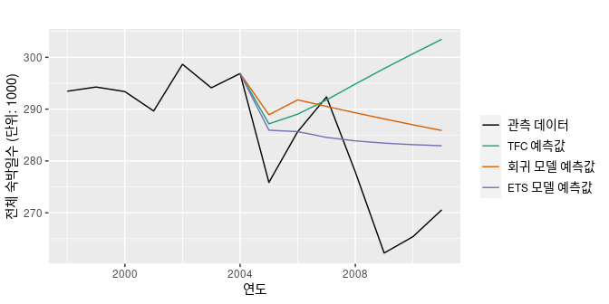

이 예제에서 무엇을 배울 수 있습니까? TFC가 ’목표치’보다 ’예측값’을 낸다고 방법론에서 분명하게 문서 형태로 나타냈지만, 목표와 예측을 혼동한 경우라고 볼 수 있겠습니까? 이 과정에서 예측가와 사용자가 충분히 잘 분리되었습니까? 반복적인 과정 자체가 개선될 수 있겠습니까? 회의에서 조정 과정이 개선될 수 있겠습니까? 그룹 회의가 낙관론을 장려한 것이겠습니까? 그 날에 국내 관광이 더 일찍 검토되었어야 했겠습니까?